# HSC Survey Results

# German Bank Survey # 1 Results from 06/08/2023

## Survey Details

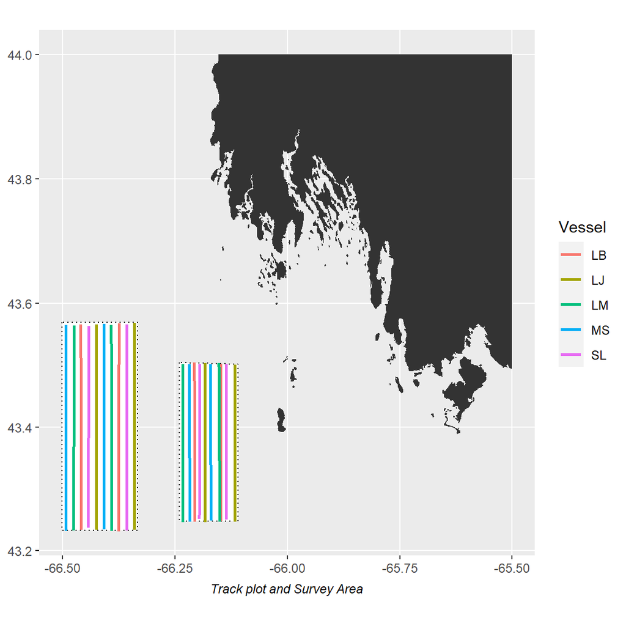

5 commercial purse seiners conducted this non-fishing survey on 06/08/2023 starting at 20:30:00.

All vessels ran two transects in the German Bank box and two transects in the Seal Island Box.

There was a plankton tow and replicate conducted and CTD cast by Lady Janice II.

No tags were applied during this survey.

Samples were obtained for target strength estimation.

### Acoustic Equipment

Each vessel was equipped with a Simrad ES38-18/200-18C combi (2-in-1) transducer prior to the survey that contains a 38kHz split beam and 200 kHz single beam transducer. Data was logged to the computer hard-drive for post-processing. All participating boats were calibrated on 38kHz before the survey.

## Survey Results

### Main Results

The results are subject to change as DFO will re-evaluate data editing, area estimation and apply a target strength.

**Preliminary biomass prediction for German Bank using standardized parallel transects is 2,687mt. The preliminary biomass estimate for Seal Island is 1,205mt.**

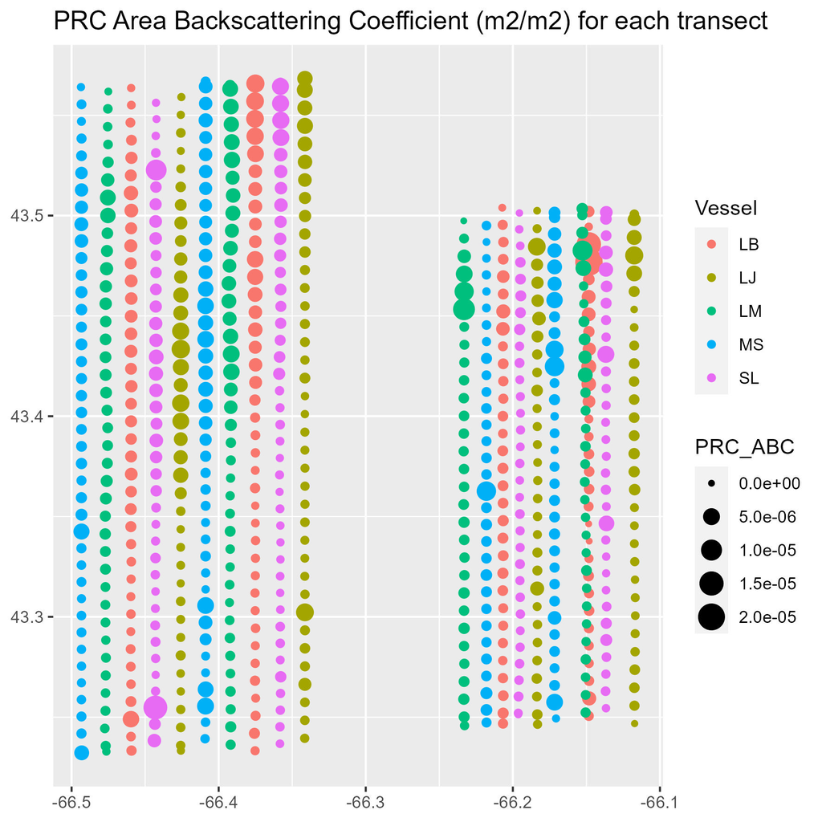

### Transect Details

Table 1: Transect Details

| Vessel | Transect # | Date/Time Start | Date/Time End | Start Lon | Start Lat | End Lon | End Lat | Location | Distance (km) | Speed |
| --- | --- | --- | --- | --- | --- | --- | --- | --- | --- | --- |
| LB | T01 | 2023-08-07 00:16:55 | 2023-08-07 02:42:05 | -66.460 | 43.566 | -66.459 | 43.233 | GB | 38.07 | 8.50 |
| LB | T02 | 2023-08-07 03:08:39 | 2023-08-07 05:29:32 | -66.376 | 43.231 | -66.375 | 43.567 | GB | 38.43 | 8.84 |
| LB | T03 | 2023-08-07 06:37:30 | 2023-08-07 08:36:50 | -66.207 | 43.504 | -66.207 | 43.247 | GB | 29.66 | 8.05 |
| LB | T04 | 2023-08-07 08:55:12 | 2023-08-07 10:55:17 | -66.149 | 43.248 | -66.148 | 43.502 | GB | 29.24 | 7.89 |
| LJ | T01 | 2023-08-07 00:23:32 | 2023-08-07 02:48:32 | -66.426 | 43.566 | -66.426 | 43.233 | GB | 37.05 | 8.28 |
| LJ | T02 | 2023-08-07 03:13:29 | 2023-08-07 05:36:54 | -66.341 | 43.234 | -66.341 | 43.568 | GB | 37.25 | 8.41 |
| LJ | T03 | 2023-08-07 06:35:16 | 2023-08-07 08:28:23 | -66.184 | 43.503 | -66.183 | 43.246 | GB | 28.66 | 8.21 |
| LJ | T04 | 2023-08-07 08:45:56 | 2023-08-07 10:35:13 | -66.117 | 43.247 | -66.117 | 43.501 | GB | 28.30 | 8.39 |
| LM | T01 | 2023-08-07 00:17:39 | 2023-08-07 02:44:04 | -66.475 | 43.564 | -66.476 | 43.233 | GB | 37.54 | 8.31 |
| LM | T02 | 2023-08-07 03:09:10 | 2023-08-07 05:25:10 | -66.392 | 43.232 | -66.392 | 43.565 | GB | 37.72 | 8.99 |
| LM | T03 | 2023-08-07 06:19:12 | 2023-08-07 08:11:52 | -66.233 | 43.502 | -66.233 | 43.246 | GB | 28.99 | 8.34 |
| LM | T04 | 2023-08-07 08:33:27 | 2023-08-07 10:26:36 | -66.151 | 43.247 | -66.153 | 43.503 | GB | 28.99 | 8.30 |
| MS | T01 | 2023-08-07 00:30:12 | 2023-08-07 02:49:57 | -66.494 | 43.565 | -66.493 | 43.232 | GB | 39.23 | 9.09 |
| MS | T02 | 2023-08-07 03:17:00 | 2023-08-07 05:38:13 | -66.409 | 43.235 | -66.409 | 43.567 | GB | 39.82 | 9.14 |
| MS | T03 | 2023-08-07 06:55:13 | 2023-08-07 08:48:41 | -66.218 | 43.502 | -66.218 | 43.247 | GB | 30.54 | 8.72 |
| MS | T04 | 2023-08-07 09:03:07 | 2023-08-07 10:58:29 | -66.170 | 43.249 | -66.172 | 43.501 | GB | 30.37 | 8.53 |
| SL | T01 | 2023-08-07 01:27:05 | 2023-08-07 03:51:43 | -66.442 | 43.563 | -66.444 | 43.237 | GB | 39.01 | 8.74 |
| SL | T02 | 2023-08-07 04:17:20 | 2023-08-07 06:40:11 | -66.358 | 43.233 | -66.358 | 43.566 | GB | 39.63 | 8.99 |
| SL | T03 | 2023-08-07 07:39:10 | 2023-08-07 09:27:33 | -66.195 | 43.502 | -66.196 | 43.251 | GB | 30.14 | 9.01 |
| SL | T04 | 2023-08-07 09:44:49 | 2023-08-07 11:33:29 | -66.137 | 43.250 | -66.136 | 43.502 | GB | 29.89 | 8.91 |

### Survey Summary

Table 2: Acoustic Survey Results

| Vessel | Transect No. | Target Strength (db/kg) | Mean Sa (/m2) | Biomass Density (kg/m2) |
| --- | --- | --- | --- | --- |
| LB | T04 | -35.5 | -56.434 | 0.008 |
| MS | T02 | -35.5 | -56.926 | 0.007 |
| LM | T02 | -35.5 | -57.052 | 0.007 |
| LB | T02 | -35.5 | -57.300 | 0.007 |
| MS | T04 | -35.5 | -57.721 | 0.006 |
| SL | T01 | -35.5 | -57.853 | 0.006 |
| LJ | T01 | -35.5 | -58.000 | 0.006 |
| LM | T03 | -35.5 | -58.274 | 0.005 |
| LJ | T02 | -35.5 | -59.096 | 0.004 |
| SL | T02 | -35.5 | -59.209 | 0.004 |
| LB | T01 | -35.5 | -59.304 | 0.004 |
| LM | T04 | -35.5 | -59.755 | 0.004 |
| MS | T01 | -35.5 | -59.762 | 0.004 |
| LM | T01 | -35.5 | -59.763 | 0.004 |
| LJ | T04 | -35.5 | -60.053 | 0.004 |
| SL | T04 | -35.5 | -60.327 | 0.003 |
| LJ | T03 | -35.5 | -60.523 | 0.003 |
| MS | T03 | -35.5 | -60.717 | 0.003 |
| LB | T03 | -35.5 | -60.732 | 0.003 |
| SL | T03 | -35.5 | -64.265 | 0.001 |

Note:  
Transects are listed from greatest to least backscatter.

Table 3: Survey Summary Table

| Layer | Target Strength | Area (km2) | Mean Sa | Density (kg/m2) | Biomass (tons) | Percent Area | Percent Biomass | Standard Error (tons) | Standard Error (%) |
| --- | --- | --- | --- | --- | --- | --- | --- | --- | --- |
| German Bank | -35.5 | 511 | -58.2923 | 0.0053 | 2,686.514 | NA | NA | 219.49 | 8.17 |
| Seal Island | -35.5 | 299 | -59.4455 | 0.0040 | 1,205.361 | NA | NA | 180.48 | 14.97 |
| School Survey | NA | NA | NA | NA | NA | NA | NA | NA | NA |

### Greatest Backscatter

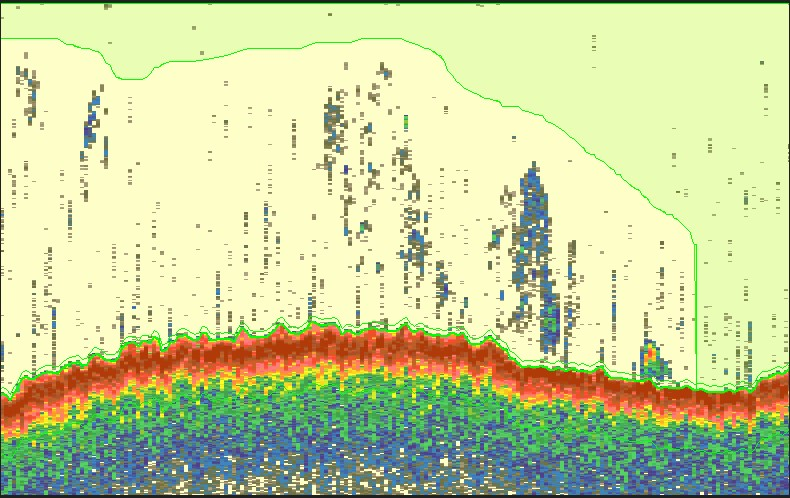

A snip from the transect with the greatest backscatter

The single point with the largest backscatter density (PRC) was recorded by **LB**, at the following location:

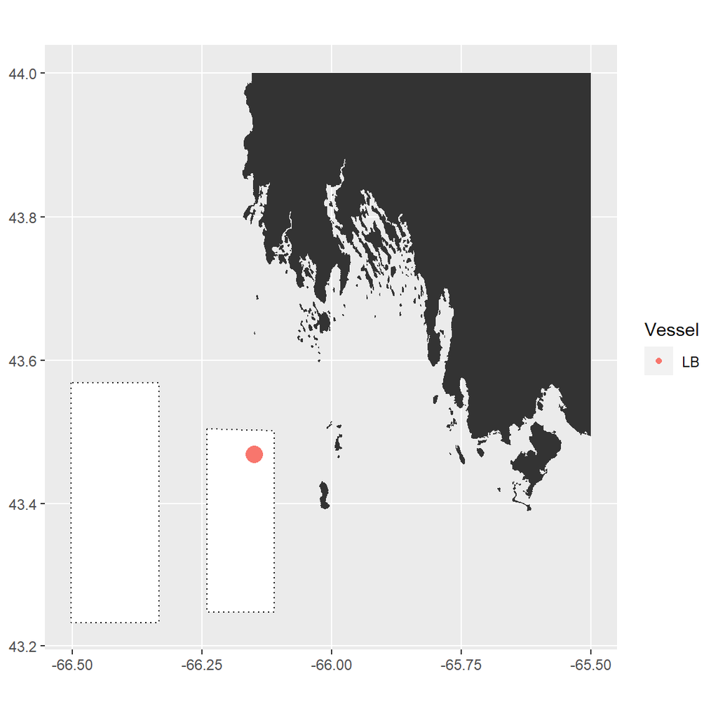

The transect with the overall largest biomass was recorded by **LB**, at the following location:

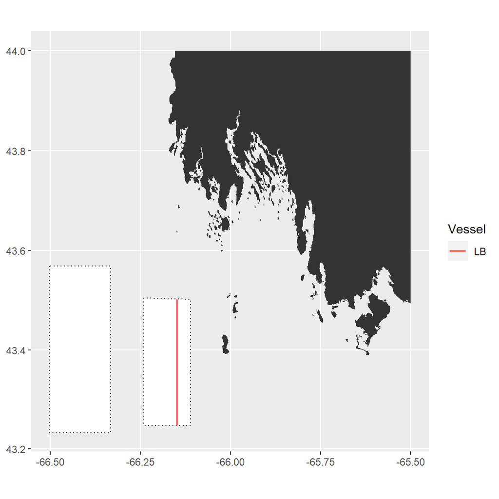

### Annual Summaries

Table 4: Annual Comparison Table

| Ground | Survey Number | Current Year Survey Date | Current Year HSC Estimate | Current Year HSC Turnover Adjusted | Previous Year Survey Date | Previous Year HSC Estimate | Previous Year HSC Turnover Adjusted | Previous Year DFO Estimate | Previous Year DFO Turnover Adjusted |
| --- | --- | --- | --- | --- | --- | --- | --- | --- | --- |
| German Bank | 1 | 2023-08-06 | 3,891.876 | NA | 2022-08-14 | 7,352 | 7,352 | 22,081 | 22,081 |
| German Bank | 2 | NA | NA | NA | 2022-08-28 | 4,659 | 3,225 | 11,699 | 7,393 |
| German Bank | 3 | NA | NA | NA | 2022-09-11 | 7,452 | 6,279 | 11,902 | 8,826 |
| German Bank | 4 | NA | NA | NA | 2022-09-25 | 62,399 | 60,778 | 12,503 | 9,761 |
| German Bank | 5 | NA | NA | NA | 2022-10-10 | NA | NA | 20,247 | 17,675 |
| German Bank | 6 | NA | NA | NA | 2022-10-23 | NA | NA | 15,565 | 10,823 |

Table 5: Annual Summary Table

| Year | Ground | HSC Estimate | HSC Turnover Adjusted | DFO Estimate | DFO Turnover Adjusted |
| --- | --- | --- | --- | --- | --- |
| 2022 | German Bank | NA | NA | 93,997 | 76,559 |
| 2023 | German Bank | 3,891.876 | NA | NA | NA |

## Tagging, Plankton, and CTD Data

### Tag Data

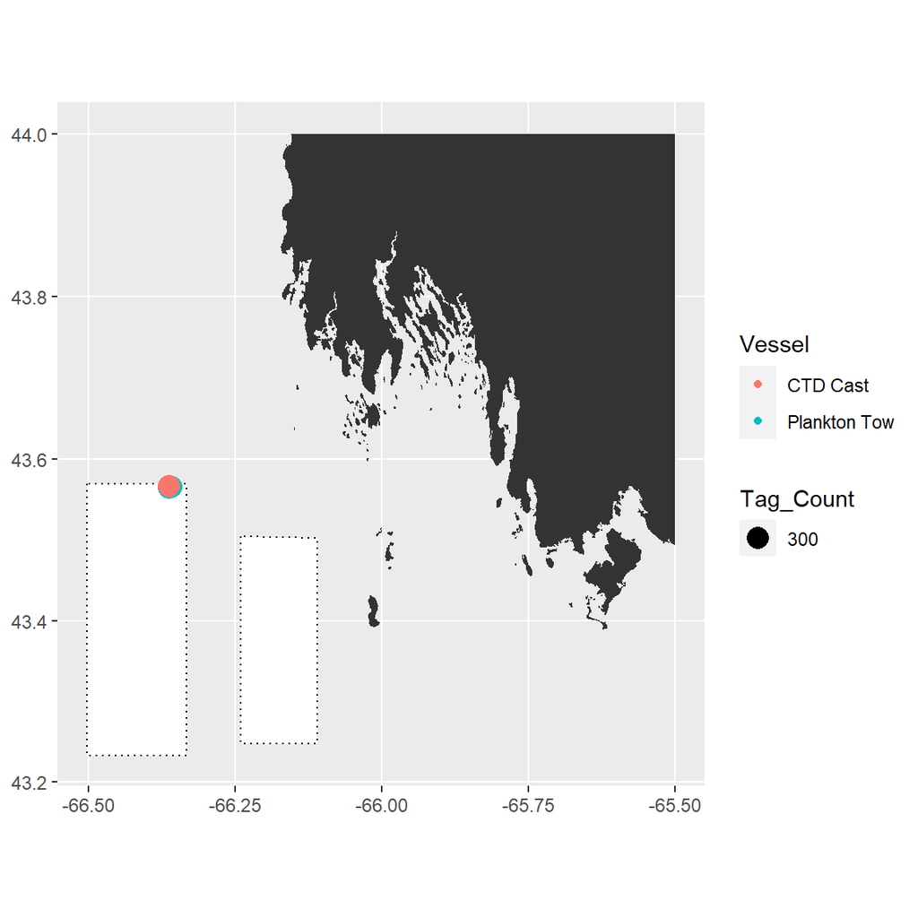

| Vessel | Tags |
| --- | --- |

### Plankton Data

#### Tow Summary Table

|  | Tow 1 | Tow 2 |
| --- | --- | --- |
| **Base Details** |  |  |
| Vessel | Lady Janice II | Lady Janice II |
| Set Number | GB2023-01 | GB2023-02 |
| Ground | GB | GB |
| Date | 06/08/2023 | 06/08/2023 |
| Wind Direction (km/h) | W | W |
| Swell (m) | 0 | 0 |
| Air Temp (c) | 17 | 17 |
| **Tow Details** |  |  |
| Tow Start | 18:55:00 | 19:10:00 |
| Tow End | 19:05:00 | 19:20:00 |
| Start Lat | 43.56483 | 43.56417 |
| End Lat | 43.56283 | 43.56717 |
| Start Lon | -66.35800 | -66.36267 |
| End Lon | -66.36233 | -66.35633 |
| Avg Tow Depth (m) | NA | 0.9786781 |
| Speed | 2.1 | 2.4 |
| Heading | 200 | 30 |
| Tide Direction | against | with |
| **Other Data Collection** |  |  |
| Flow Start | 540248 | 563471 |
| Flow End | 563471 | 600019 |
| No. Revolutions | 23223 | 36548 |
| Distance (m) | 624.0717 | 982.1544 |
| Volume | 1960.521 | 3085.438 |
| Secchi Disappear (m) | 10 | 10 |
| Secchi Reappear (m) | 9 | 9 |

#### Tow Depth Profiles

[figure not shown]

Plankton tow depth profile #1

[figure not shown]

Plankton tow depth profile #2

#### Captured plankton

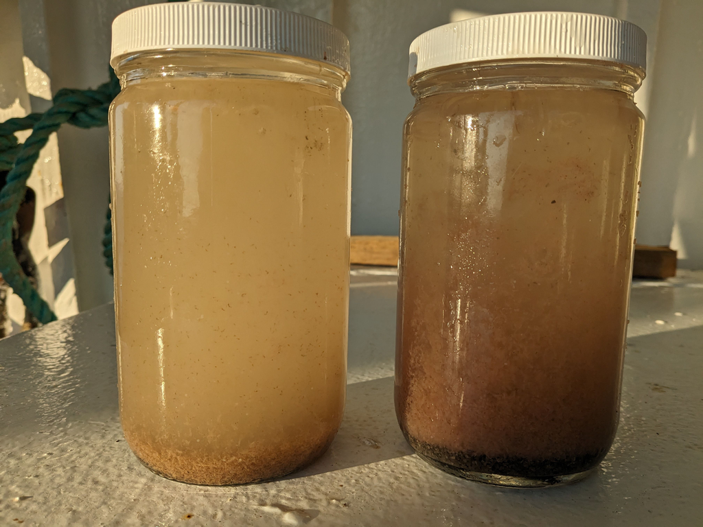

Captured plankton from the surface tows

### CTD Data

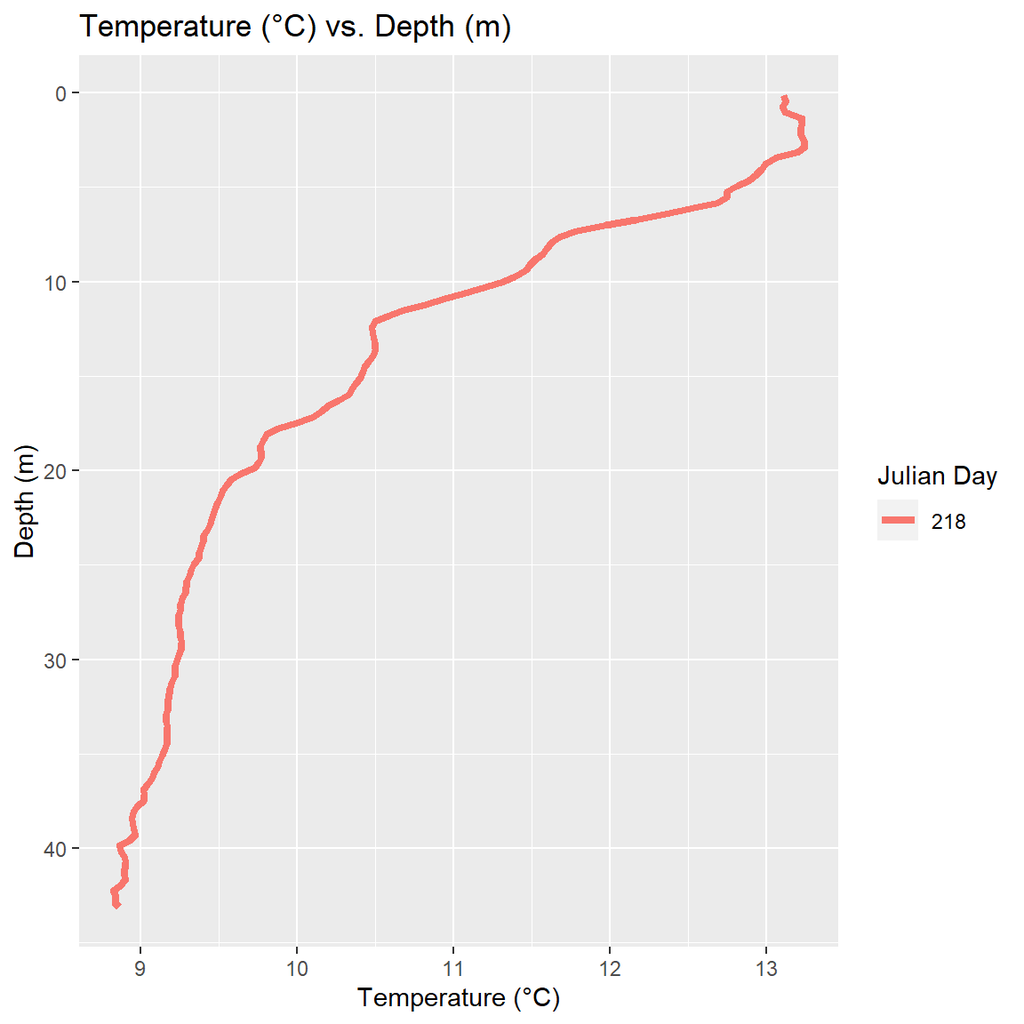

CTD depth profiles for all 2023 German Bank surveys so far.

#### Sea surface temperatures

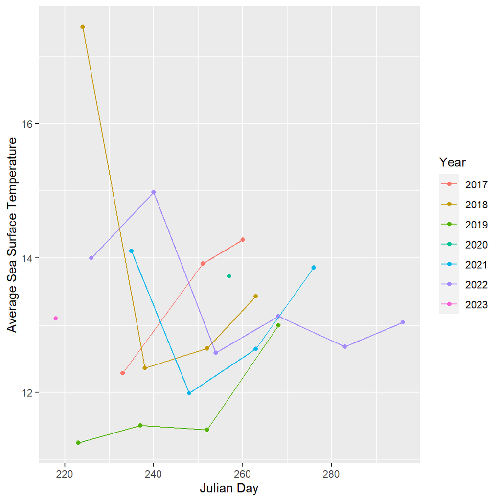

Annual average sea surface temperatures (SST) for German Bank.

## Vessel Performance

### Speed

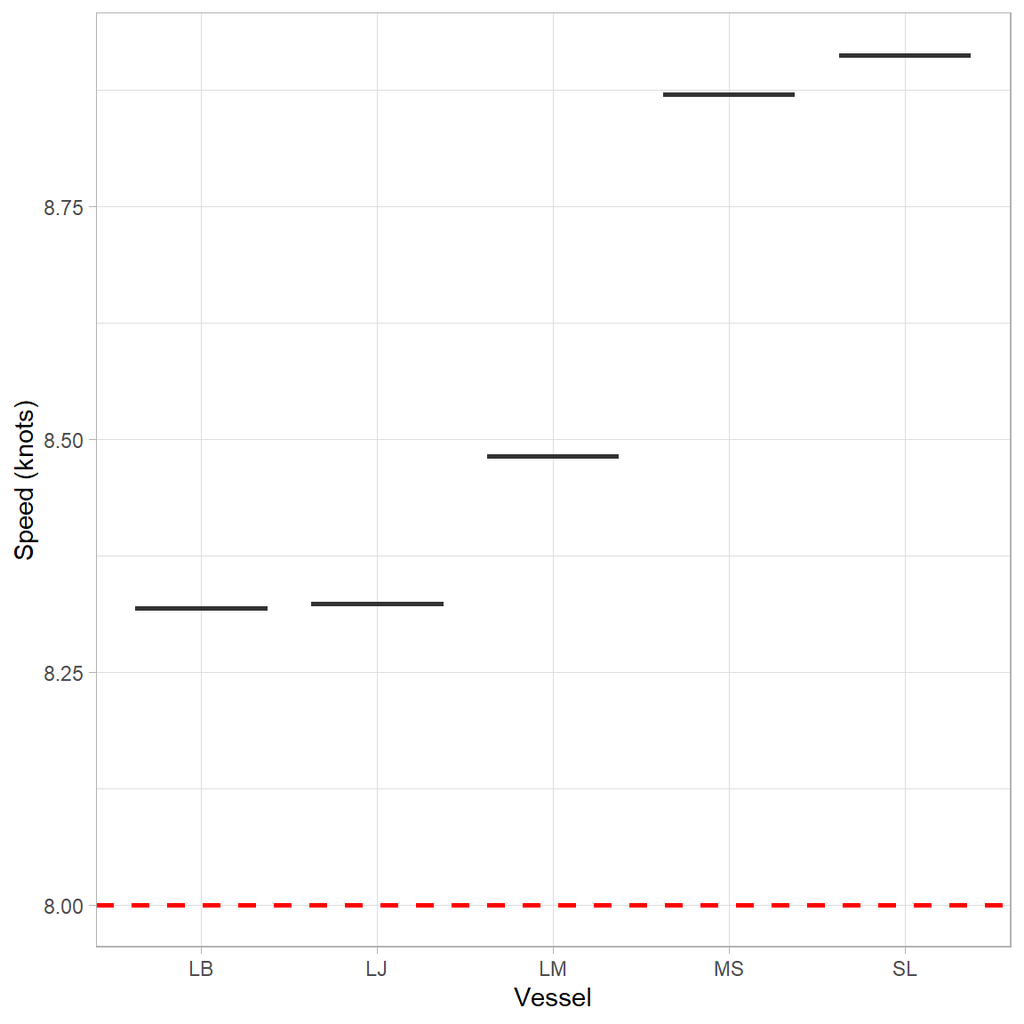

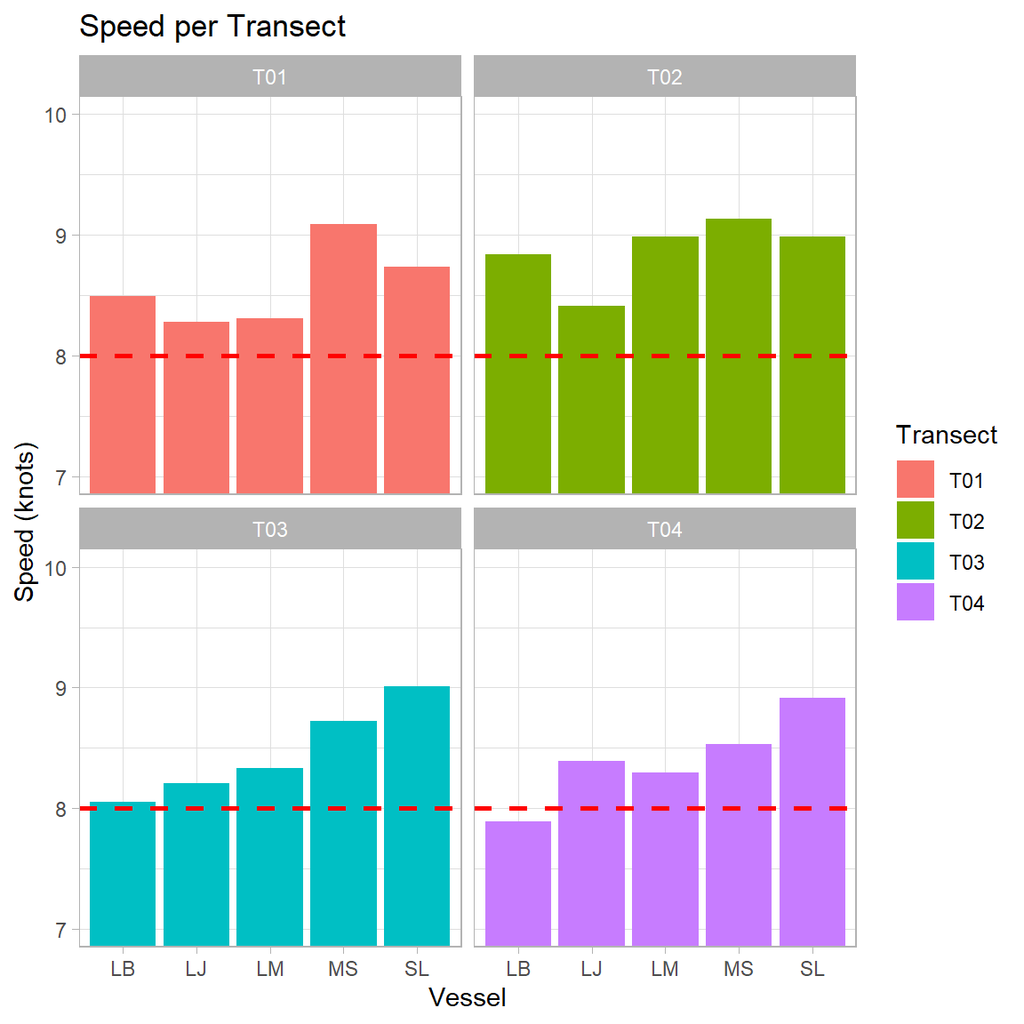

Average vessel speed was 8.58. This is above the 8 knot requirement; vessels are urged to slow down to prevent backscatter noise from interfering with the acoustic data.

### Distance

[figure not shown]

No significant distance was cut from the planned lines; vessels covered the planned area well.